## Tarea 3

Programa Experto en Inteligencia Artificial con Python  
ML3003 - Deep Learning  
Estudiante: Natalia Bonilla Villalobos.  
**Redes Neuronales | Convolutional Neural Networks (CNN)**

# Menú

- Ejercicio 1
- Ejercicio 2
- Ejercicio 3
- Ejercicio 4

```python
# LIBRERÍAS ESTÁNDAR
import os                     # Manejo de archivos y rutas del sistema operativo
import warnings               # Control y supresión de advertencias

# MANEJO DE DATOS
import pandas as pd           # Manipulación y análisis de datos en DataFrames
import numpy as np            # Cálculo numérico y manejo de arreglos

# VISUALIZACIÓN
import matplotlib.pyplot as plt   # Gráficos básicos
import seaborn as sns             # Gráficos estadísticos más elaborados
from matplotlib import colors as mcolors  # Manejo de colores en gráficos

# SCIKIT-LEARN (Machine Learning)
from sklearn.model_selection import train_test_split   # División en entrenamiento y prueba
from sklearn.metrics import confusion_matrix           # Matriz de confusión

from sklearn.pipeline import Pipeline                  # Encadenar preprocesamiento y modelo
from sklearn.compose import ColumnTransformer          # Aplicar transformaciones por columnas
from sklearn.preprocessing import OneHotEncoder        # Codificación de variables categóricas
from sklearn.preprocessing import StandardScaler       # Escalamiento de variables numéricas
from sklearn.preprocessing import LabelEncoder

# DEEP LEARNING (TensorFlow / Keras)
from tensorflow.keras.models import Sequential         # Modelo secuencial de redes neuronales
# from tensorflow.keras.layers import Dense              # Capas densas (fully connected)

# Manejo imagenes
import re  # Permite trabajar con expresiones regulares (útil para filtrar nombres de archivos)
import cv2  # OpenCV: procesamiento de imágenes (leer, redimensionar, transformar imágenes)
import tensorflow.keras as keras  # API de alto nivel para construir y entrenar redes neuronales

from tensorflow.keras.utils import to_categorical
# Convierte etiquetas numéricas en codificación one-hot (necesario para clasificación multiclase)

from tensorflow.keras.layers import Dense, Dropout, Flatten, Activation
# Dense: capa totalmente conectada
# Dropout: regularización para evitar overfitting
# Flatten: convierte matrices 2D/3D en vectores 1D
# Activation: permite definir funciones de activación

from tensorflow.keras.layers import Conv2D, MaxPooling2D
# Conv2D: capa convolucional (extrae características de imágenes)
# MaxPooling2D: reduce dimensionalidad manteniendo características importantes

from tensorflow.keras.layers import LeakyReLU
# Variante de ReLU que evita el problema de neuronas muertas


warnings.filterwarnings('ignore')  # Oculta warnings en la salida
```

```python
def indices_general(MC, nombres = None):
  """
    Devuelve métricas básicas desde una matriz de confusión.

    Parámetros:
      MC (np.ndarray): matriz de confusión (filas=reales, columnas=predichas).
      nombres (list | None): nombres de clases para columnas (opcional).

    Retorna:
      dict con:
        - Matriz de Confusión
        - Precisión Global (accuracy)
        - Error Global
        - Precisión por categoría (acierto por clase / total real de la clase)
    """
  precision_global = np.sum(MC.diagonal()) / np.sum(MC)
  error_global = 1 - precision_global
  precision_categoria = pd.DataFrame(MC.diagonal() / np.sum(MC, axis = 1)).T
  if nombres != None:
    precision_categoria.columns = nombres

  return {
    "Matriz de Confusión" : MC,
    "Precisión Global" : precision_global,
    "Error Global" : error_global,
    "Precisión por categoría" : precision_categoria}
```

```python
def cargar_imagenes_desde_directorio(ruta, size=(64, 64), extensiones=("jpg","jpeg","png","bmp","tiff")):
    """
    Carga imágenes organizadas en subcarpetas (cada subcarpeta es una clase).

    Parámetros:
        ruta (str): directorio raíz donde están las carpetas de clases
        size (tuple): tamaño al que se redimensionarán las imágenes
        extensiones (tuple): extensiones permitidas

    Retorna:
        X (np.array): array de imágenes
        y (np.array): array de etiquetas (strings)
    """

    imagenes = []
    labels = []

    patron = r"\.(" + "|".join(extensiones) + r")$"

    for carpeta in next(os.walk(ruta))[1]:
        ruta_carpeta = os.path.join(ruta, carpeta)

        for archivo in next(os.walk(ruta_carpeta))[2]:
            if re.search(patron, archivo.lower()):
                try:
                    ruta_imagen = os.path.join(ruta_carpeta, archivo)
                    img = cv2.imread(ruta_imagen)

                    if img is None:
                        raise ValueError("Imagen corrupta")

                    img = cv2.resize(img, size)

                    imagenes.append(img)
                    labels.append(carpeta)

                except Exception as e:
                    print(f"No se pudo cargar la imagen: {archivo} en la carpeta: {carpeta}")

    X = np.array(imagenes)
    y = np.array(labels)

    return X, y
```

# Ejercicio 1

[20 puntos] El paquete `OpenCV` permite aplicar filtros a las imágenes, investigue como aplicar adecuadamente el filtro canny y apliquelo a la imagen `AlanTuring.jpg`. Muestre la imagen generada.

↑ Volver al Menú

Algunos de los métodos más utilizados de este paquete para trabajar con imágenes son:

cv2.imread() → Cargar una imagen desde archivo.

cv2.imshow() → Mostrar una imagen en una ventana.

cv2.resize() → Redimensionar una imagen.

cv2.flip() → Voltear imágenes horizontal o verticalmente.

cv2.rotate() → Rotar imágenes.

cv2.Canny() → Detectar bordes.

Estos métodos permiten realizar el preprocesamiento necesario antes de entrenar un modelo.

```
(1002, 752, 3)
```

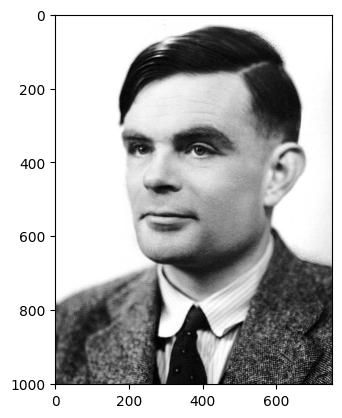

```python
AlanTuring = cv2.imread('AlanTuring.jpg')
# AlanTuring = cv2.imread('../AlanTuring.jpg')
print(AlanTuring.shape)
# print(AlanTuring)

plt.imshow(AlanTuring)
plt.show()
```

shappe = (1002, 752, 3), entonces sigue siendo rgb aunque se vea gris; (alto, ancho, 3)

```
(1002, 752, 3)
```

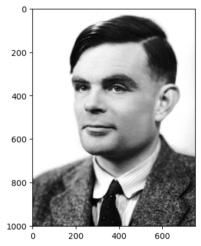

```python
imagen = cv2.imread('./AlanTuring.jpg', cv2.COLOR_BGR2GRAY)
print(imagen.shape)
plt.imshow(imagen)
plt.show()
```

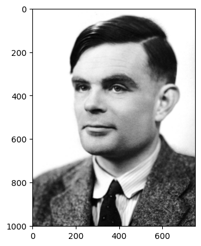

```python
#  Aplicar suavizado Gaussiano para reducir ruido
gauss = cv2.GaussianBlur(imagen, (5, 5), 0)

# cv2.imshow("suavizado", gauss)
plt.imshow(gauss, cmap='gray') #sino muestra un colormap viridis
plt.show()
```

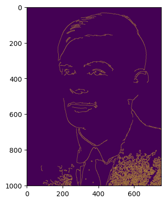

```python
# Detectamos los bordes con Canny
t_lower = 50
t_upper = 150
aperture_size = 3 # 3 (normal), 5 (más sensible), 7 (más raro)
l2gradient = True
canny = cv2.Canny(
    gauss,
    t_lower,
    t_upper,
    apertureSize=aperture_size,
    L2gradient=l2gradient)


# cv2.imshow("canny", canny)
plt.imshow(canny)
plt.show()
```

cv2.Canny(  
image = Imagen de entrada, debe ser 1 canal en escala de grises (Idealmente ya suavizada con Gauss),  
threshold1 = Límite inferior para considerar un posible borde (Gradientes menores que esto se eliminan). Filtro para ruido pequeño,  
threshold2 = Límite superior para considerar un borde fuerte(Gradientes mayores que esto borde seguro) suele ser 2 o 3 veces threshold1; Los bordes débiles solo se conservan si están conectados a uno fuerte (hysteresis),  
apertureSize = Tamaño del kernel Sobel para calcular el gradiente (Más grande: detecta variaciones más amplias, Más pequeño: más preciso en detalles finos),  
L2gradient = True: más preciso, False: más rápido)

Hhysteresis Canny no solo corta por umbral. Sino que:

- Bordes fuertes: siempre se quedan.
- Bordes débiles: solo se quedan si están conectados a uno fuerte.
- Lo demás: se elimina. Eso hace que sea mucho más inteligente que un simple threshold.

# Ejercicio 2

[20 puntos] Para cada capa, calcule la cantidad de variables generadas ("feature mapping"), es decir, el tamaño de las matrices. Además, calcule el número de parámetros entrenables. La notación sigue la siguiente convención:

- a) $CONV-K-N$: denota una capa convolucional con $N$ Filtros, cada uno de tamaño. $KxK$, los parámetros "`padding`" y "`stride`" serán siempre 0 y 1 respectivamente.
- b) $POOL-K-S$: indica una capa de "pooling" de tamaño $KxK$ con "`stride`" (zancada) S y "`padding`" 0.
- c) $ReLU$: indica la aplicación de la función de activación `ReLU`.
- d) $FLATTEN$: denota la capa aplanada.
- e) $FC-N$: representa una capa completamente conectada (Fully-Connected) con $N$ neuronas.

↑ Volver al Menú

```python
# Formulas para conv y param, pool, flatten y fc
def CONV(W, K, P, S):
    conv = (W - K + 2*P)/S +1
    # print(conv)
    return conv

def param_entrenables(K, C, N):
    param = (K * K * C + 1) * N
    # print('(', K, '*',  K, '*',  C, '+', 1, ')', '*', N)
    print('# de param entrenables:', param)
    return param

def POOL(W, K, S):
    pool = (W-K)/S +1
    # print(pool)
    return pool

def FLATTEN(H, W, C):
    flat = H*W*C
    print(flat)
    return flat

def FC(M, N): #fullconnected
    full = M * N + N
    print(full)
    return full
```

## CONV3-8

```python
# CONV-3-8
# CONV-K-N
# INPUT = 32x32x3
K_filtro = 3 # 3X3 -> K X K
N_filtros = 8 # -> N
Padding = 0 # -> P
Stride = 1 # -> S
Width = 32 # -> W
Canal = 3

salidaConv1 = CONV(Width, K_filtro, Padding, Stride)
param1 = param_entrenables(K_filtro, Canal, N_filtros)
print('Feature Mapping:',int(salidaConv1),'X',int(salidaConv1),'X',N_filtros)
```

```
# de param entrenables: 224
Feature Mapping: 30 X 30 X 8
```

## POOL2-2

```python
# POOL-2-2
# POOL-K-S
K_filtro = 2 # 2X2 -> K X K
Stride = 2 # -> S
Width = salidaConv1 # Nuevo
salidaPool1 = POOL(Width, K_filtro, Stride)
print('Feature Mapping:',int(salidaPool1),'X',int(salidaPool1),'X',N_filtros)
```

```
Feature Mapping: 15 X 15 X 8
```

## CONV3-16

```python
# CONV-3-16
# CONV-K-N
K_filtro = 3 # 3X3 -> K X K
N_filtros = 16 # -> N
Padding = 0 # -> P
Stride = 1 # -> S
Width = salidaPool1 # -> W
Canal = 8

salidaConv2 = CONV(Width, K_filtro, Padding, Stride)
param2 = param_entrenables(K_filtro, Canal, N_filtros)
print('Feature Mapping:',int(salidaConv2),'X',int(salidaConv2),'X',N_filtros)
```

```
# de param entrenables: 1168
Feature Mapping: 13 X 13 X 16
```

## POOL3-1

```python
# POOL-3-1
# POOL-K-S
K_filtro = 3 # 3X3 -> K X K
Stride = 1 # -> S
Width = salidaConv2 # Nuevo
Canal = 16
salidaPool2 = POOL(Width, K_filtro, Stride)
print('Feature Mapping:',int(salidaPool2),'X',int(salidaPool2),'X',N_filtros)
```

```
Feature Mapping: 11 X 11 X 16
```

## FLATTEN

```python
W = salidaPool2
H = salidaPool2

flat = FLATTEN(H, W, Canal)
```

```
1936.0
```

## FC-10

```python
# FC-N
# FC-10

N = 10
full_Connected = FC(flat, N)
```

```
19370.0
```

## Tabla Final

[output not shown]

# Ejercicio 3

[30 puntos] En india la moneda que utilizan se conoce como la rupia. El archivo `monedas.zip` es un comprimido que contiene imágenes de las monedas de 1 rupia, 2 rupias y 5 rupias de la India, con estos datos realice lo siguiente:

- a) Descomprima el archivo, luego cargue las imágenes y obtenga la etiqueta correspondiente para cada imagen.
- b) Divida la tabla utilizando un 90% para entrenamiento y un 10% para pruebas.
- c) Grafique una moneda de cada tipo de monedas (1 rupia, 2 rupias y 5 rupias).
- d) Genere dos modelos de Redes Neuronales Convolucionales con las capas y parámetros que considere más adecuados. Muestre un resumen del modelo.
- e) Para cada modelo obtenga los índices de precisión, compare e interprete los resultados.
- f) Determine cuál de los 2 modelos anteriores fue el mejor. Luego con dicho modelo genere uno nuevo, pero esta vez utilizando todos los datos. Guarde el modelo en un archivo.
- g) Obtenga y cargue fotos de al menos 10 monedas diferentes. Luego con ayuda del modelo realice una predicción de dichas imágenes. Muestre y comente los resultados. Debe utilizar el modelo que se guardo en el punto anterior.

↑ Volver al Menú

## Parte 1

- a) Descomprima el archivo, luego cargue las imágenes y obtenga la etiqueta correspondiente para cada imagen.

```python
from google.colab import drive
drive.mount('/content/drive/')
ruta = "/content/drive/MyDrive/Promidat/w3/monedas"
```

```python
# ruta = "monedas" # directorio principal donde están los datos.
imagenes, labels = cargar_imagenes_desde_directorio(ruta)
```

```python
x = np.array(imagenes, dtype = np.int64)
y = np.array(labels)
y[:5]
```

```
array(['1rupia', '1rupia', '1rupia', '1rupia', '1rupia'], dtype='<U7')
```

```python
print(
  'Total de individuos: ', len(x),
  '\nNúmero total de salidas: ', len(np.unique(y)),
  '\nClases de salida: ', np.unique(y))
```

```
Total de individuos:  1050
Número total de salidas:  3
Clases de salida:  ['1rupia' '2rupias' '5rupias']
```

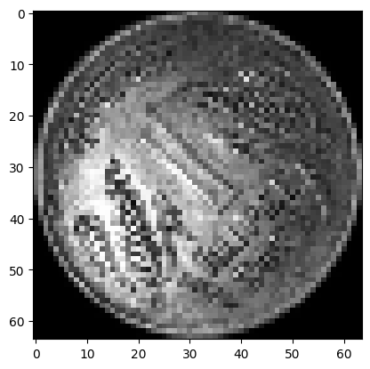

```python
plt.imshow(x[0])
plt.show()
```

```python
clases, conteo = np.unique(y, return_counts=True)

for clase, cantidad in zip(clases, conteo):
    print(f"{clase}: {cantidad}")
```

```
1rupia: 350
2rupias: 350
5rupias: 350
```

## Parte 2

- b) Divida la tabla utilizando un 90% para entrenamiento y un 10% para pruebas.

```python
X = x / 255 # Normalización de píxeles a valores entre 0 y 1.
print(X[0].shape) # Matriz 2D de 64x64 con 3  canales/valores por cada píxel(RGB)
X[0]
```

```
(64, 64, 3)
```

[output not shown]

```python
# Recodificamos la variable a predecir a enteros de 0 a num_clases-1
encoder = LabelEncoder()
y = encoder.fit_transform(y)
y[0:5]
encoder.classes_
```

```
array(['1rupia', '2rupias', '5rupias'], dtype='<U7')
```

```python
X_train, X_test, y_train, y_test = train_test_split(X, y, train_size = 0.90)#, random_state = 0)
```

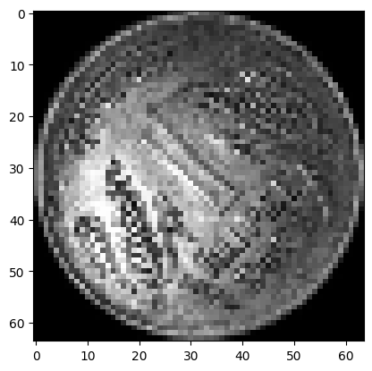

```python
plt.imshow(x[0])
plt.show()
```

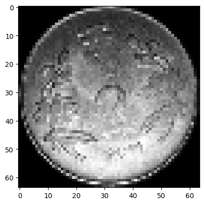

```python
plt.imshow(x[650])
plt.show()
```

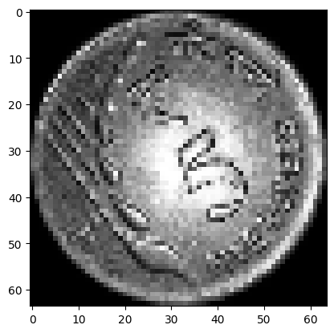

```python
plt.imshow(x[800])
plt.show()
```

## Parte 4

- d) Genere dos modelos de Redes Neuronales Convolucionales con las capas y parámetros que considere más adecuados. Muestre un resumen del modelo.

### Modelo 1

```python
modelo_m1 = Sequential() # añadir caas

# Capa de convolución para extraer características importantes de las imágenes.
#CONV3-64
modelo_m1.add(
  Conv2D(64, kernel_size=(3, 3), activation='linear', padding='same', input_shape=(64, 64, 3))  # Capa de entrada con tamaño 64x64 y 3 canales (RGB)
)
# Función de activación LeakyReLU para evitar neuronas muertas.
modelo_m1.add(LeakyReLU(alpha=0.1))

# Capa de MaxPooling para reducir las dimensiones espaciales, conservando las características más importantes.
modelo_m1.add(MaxPooling2D((2, 2), padding='same'))

# Dropout para regularizar la red y prevenir el sobreajuste durante el entrenamiento.
modelo_m1.add(Dropout(0.5))

# Aplana la salida 2D de las capas anteriores a un vector 1D para que pueda ser procesada por capas densas.
modelo_m1.add(Flatten())

# Capa densa con 32 neuronas, usando activación lineal.
modelo_m1.add(Dense(32, activation='linear'))

# Función de activación LeakyReLU para la capa densa.
modelo_m1.add(LeakyReLU(alpha=0.1))

# Dropout adicional para evitar el sobreajuste en las capas densas.
modelo_m1.add(Dropout(0.5))

# Capa de salida con 3 neuronas (para 3 clases), usando la activación softmax para clasificación multiclase.
modelo_m1.add(Dense(3, activation='softmax'))

# Mostrar un resumen de la arquitectura del modelo.
modelo_m1.summary()
```

```
Model: "sequential"
```

```
┏━━━━━━━━━━━━━━━━━━━━━━━━━━━━━━━━━┳━━━━━━━━━━━━━━━━━━━━━━━━┳━━━━━━━━━━━━━━━┓
┃ Layer (type)                    ┃ Output Shape           ┃       Param # ┃
┡━━━━━━━━━━━━━━━━━━━━━━━━━━━━━━━━━╇━━━━━━━━━━━━━━━━━━━━━━━━╇━━━━━━━━━━━━━━━┩
│ conv2d (Conv2D)                 │ (None, 64, 64, 64)     │         1,792 │
├─────────────────────────────────┼────────────────────────┼───────────────┤
│ leaky_re_lu (LeakyReLU)         │ (None, 64, 64, 64)     │             0 │
├─────────────────────────────────┼────────────────────────┼───────────────┤
│ max_pooling2d (MaxPooling2D)    │ (None, 32, 32, 64)     │             0 │
├─────────────────────────────────┼────────────────────────┼───────────────┤
│ dropout (Dropout)               │ (None, 32, 32, 64)     │             0 │
├─────────────────────────────────┼────────────────────────┼───────────────┤
│ flatten (Flatten)               │ (None, 65536)          │             0 │
├─────────────────────────────────┼────────────────────────┼───────────────┤
│ dense (Dense)                   │ (None, 32)             │     2,097,184 │
├─────────────────────────────────┼────────────────────────┼───────────────┤
│ leaky_re_lu_1 (LeakyReLU)       │ (None, 32)             │             0 │
├─────────────────────────────────┼────────────────────────┼───────────────┤
│ dropout_1 (Dropout)             │ (None, 32)             │             0 │
├─────────────────────────────────┼────────────────────────┼───────────────┤
│ dense_1 (Dense)                 │ (None, 3)              │            99 │
└─────────────────────────────────┴────────────────────────┴───────────────┘
```

```
 Total params: 2,099,075 (8.01 MB)
```

```
 Trainable params: 2,099,075 (8.01 MB)
```

```
 Non-trainable params: 0 (0.00 B)
```

```python
modelo_m1.compile(loss = "sparse_categorical_crossentropy", optimizer = "adam", metrics = ["accuracy"])
modelo_m1.fit(X_train, y_train, batch_size = 64, epochs = 50, verbose = 0)
```

```
<keras.src.callbacks.history.History at 0x7d8f38340f50>
```

### Modelo 2

```python
modelo_m2 = Sequential() # añadir caas

# Capa de convolución para extraer características importantes de las imágenes.
#CONV3-72
modelo_m2.add(
    Conv2D(
        32,
        kernel_size=(3,3),
        # strides=1,  # Zancada
        padding='same',   # relleno. same -> añade ceros alrededor para que la salida tenga el mismo ancho/alto que la entrada
        activation='relu', # linear
        input_shape=(64, 64, 3)  # Capa de entrada con tamaño 64x64 y 3 canales (RGB)
    )
)
modelo_m2.add(LeakyReLU(alpha=0.1))  # # Función de activación LeakyReLU para evitar neuronas muertas.
modelo_m2.add(MaxPooling2D((3, 3), strides=2)) # valid -> significa sin relleno, reduciendo la dimensión de salida (<= entrada) # padding='same'

modelo_m2.add(
    Conv2D(
        64,
        kernel_size=(3,3),
        strides=1, # Zancada
        padding='same',
        activation='relu' # softplus
    )
)
modelo_m2.add(MaxPooling2D((3, 3), strides=2))
modelo_m2.add(Flatten())
modelo_m2.add(Dense(100, activation='relu'))
modelo_m2.add(Dropout(0.3))
modelo_m2.add(Dense(3, activation='softmax'))

# Mostrar un resumen de la arquitectura del modelo.
modelo_m2.summary()
```

```
Model: "sequential_1"
```

```
┏━━━━━━━━━━━━━━━━━━━━━━━━━━━━━━━━━┳━━━━━━━━━━━━━━━━━━━━━━━━┳━━━━━━━━━━━━━━━┓
┃ Layer (type)                    ┃ Output Shape           ┃       Param # ┃
┡━━━━━━━━━━━━━━━━━━━━━━━━━━━━━━━━━╇━━━━━━━━━━━━━━━━━━━━━━━━╇━━━━━━━━━━━━━━━┩
│ conv2d_1 (Conv2D)               │ (None, 64, 64, 32)     │           896 │
├─────────────────────────────────┼────────────────────────┼───────────────┤
│ leaky_re_lu_2 (LeakyReLU)       │ (None, 64, 64, 32)     │             0 │
├─────────────────────────────────┼────────────────────────┼───────────────┤
│ max_pooling2d_1 (MaxPooling2D)  │ (None, 31, 31, 32)     │             0 │
├─────────────────────────────────┼────────────────────────┼───────────────┤
│ conv2d_2 (Conv2D)               │ (None, 31, 31, 64)     │        18,496 │
├─────────────────────────────────┼────────────────────────┼───────────────┤
│ max_pooling2d_2 (MaxPooling2D)  │ (None, 15, 15, 64)     │             0 │
├─────────────────────────────────┼────────────────────────┼───────────────┤
│ flatten_1 (Flatten)             │ (None, 14400)          │             0 │
├─────────────────────────────────┼────────────────────────┼───────────────┤
│ dense_2 (Dense)                 │ (None, 100)            │     1,440,100 │
├─────────────────────────────────┼────────────────────────┼───────────────┤
│ dropout_2 (Dropout)             │ (None, 100)            │             0 │
├─────────────────────────────────┼────────────────────────┼───────────────┤
│ dense_3 (Dense)                 │ (None, 3)              │           303 │
└─────────────────────────────────┴────────────────────────┴───────────────┘
```

```
 Total params: 1,459,795 (5.57 MB)
```

```
 Trainable params: 1,459,795 (5.57 MB)
```

```
 Non-trainable params: 0 (0.00 B)
```

```python
modelo_m2.compile(loss = "sparse_categorical_crossentropy", optimizer = "adam", metrics = ["accuracy"])
modelo_m2.fit(X_train, y_train, batch_size = 64, epochs = 50, verbose = 0)
```

```
<keras.src.callbacks.history.History at 0x7d8f38341850>
```

## Parte 5

- e) Para cada modelo obtenga los índices de precisión, compare e interprete los resultados.

```python
pred1 = modelo_m1.predict(X_test, verbose = 0)
pred1 = np.argmax(pred1, axis = 1)
pred1 = encoder.inverse_transform(pred1)
print(pred1[:10])

y_test = encoder.inverse_transform(y_test)

MC1 = confusion_matrix(y_test, pred1, labels = encoder.classes_)
indices1= indices_general(MC1, list(encoder.classes_))
for k in indices1:
  print("\n%s:\n%s" % (k, str(indices1[k])))
```

```
['1rupia' '1rupia' '2rupias' '1rupia' '2rupias' '5rupias' '2rupias'
 '5rupias' '2rupias' '5rupias']

Matriz de Confusión:
[[37  1  0]
 [ 0 35  0]
 [ 0  0 32]]

Precisión Global:
0.9904761904761905

Error Global:
0.00952380952380949

Precisión por categoría:
     1rupia  2rupias  5rupias
0  0.973684      1.0      1.0
```

```python
pred2 = modelo_m2.predict(X_test, verbose = 0)
pred2 = np.argmax(pred2, axis = 1)
pred2 = encoder.inverse_transform(pred2)
print(pred2[:10])

MC2 = confusion_matrix(y_test, pred2, labels = encoder.classes_)
indices2= indices_general(MC2, list(encoder.classes_))
for k in indices2:
  print("\n%s:\n%s" % (k, str(indices2[k])))
```

```
['1rupia' '1rupia' '5rupias' '1rupia' '2rupias' '5rupias' '2rupias'
 '5rupias' '2rupias' '5rupias']

Matriz de Confusión:
[[36  1  1]
 [ 0 35  0]
 [ 0  0 32]]

Precisión Global:
0.9809523809523809

Error Global:
0.01904761904761909

Precisión por categoría:
     1rupia  2rupias  5rupias
0  0.947368      1.0      1.0
```

El "Modelo 1" con solamente 1 capa convolucional y los filtros:

- LeakyReLU
- MaxPooling
- Dropout
- Flatten
- Dense

Tuvieron 'mejor' desempeño en comparación con el "Modelo 2" el cual usó 2 capas y varios filtros.

El "Modelo 2" tuvo buenas metricas, pero tiende a confundir, 5rupias con 1rupia y 2rupia con 1rupia.

## Parte 6

- f) Determine cuál de los 2 modelos anteriores fue el mejor. Luego con dicho modelo genere uno nuevo, pero esta vez utilizando todos los datos. Guarde el modelo en un archivo.

Por las razones anteriores (mejor prediccion, y mejores indices), el "Modelo 1", es el modelo que se escogió como el "mejor" modelo.

### **Modelo 1**

```python
modelo_m1 = Sequential() # añadir caas

# Capa de convolución para extraer características importantes de las imágenes.
#CONV3-64
modelo_m1.add(
  Conv2D(64, kernel_size=(3, 3), activation='linear', padding='same', input_shape=(64, 64, 3))  # Capa de entrada con tamaño 64x64 y 3 canales (RGB)
)
# Función de activación LeakyReLU para evitar neuronas muertas.
modelo_m1.add(LeakyReLU(alpha=0.1))

# Capa de MaxPooling para reducir las dimensiones espaciales, conservando las características más importantes.
modelo_m1.add(MaxPooling2D((2, 2), padding='same'))

# Dropout para regularizar la red y prevenir el sobreajuste durante el entrenamiento.
modelo_m1.add(Dropout(0.5))

# Aplana la salida 2D de las capas anteriores a un vector 1D para que pueda ser procesada por capas densas.
modelo_m1.add(Flatten())

# Capa densa con 32 neuronas, usando activación lineal.
modelo_m1.add(Dense(32, activation='linear'))

# Función de activación LeakyReLU para la capa densa.
modelo_m1.add(LeakyReLU(alpha=0.1))

# Dropout adicional para evitar el sobreajuste en las capas densas.
modelo_m1.add(Dropout(0.5))

# Capa de salida con 3 neuronas (para 3 clases), usando la activación softmax para clasificación multiclase.
modelo_m1.add(Dense(3, activation='softmax'))

# Mostrar un resumen de la arquitectura del modelo.
# modelo_m1.summary()

modelo_m1.compile(loss = "sparse_categorical_crossentropy", optimizer = "adam", metrics = ["accuracy"])
modelo_m1.fit(X, y, batch_size = 64, epochs = 50, verbose = 0)

# modelo_m1.save("cnn_rupias.h5py")
modelo_m1.save("cnn_rupias_m1.keras")
modelo_m1.save("cnn_rupias_m1.h5")
```

```
WARNING:absl:You are saving your model as an HDF5 file via `model.save()` or `keras.saving.save_model(model)`. This file format is considered legacy. We recommend using instead the native Keras format, e.g. `model.save('my_model.keras')` or `keras.saving.save_model(model, 'my_model.keras')`.
```

## Parte 7

- g) Obtenga y cargue fotos de al menos 10 monedas diferentes. Luego con ayuda del modelo realice una predicción de dichas imágenes. Muestre y comente los resultados. Debe utilizar el modelo que se guardo en el punto anterior.

```python
from tensorflow.keras.models import load_model

modelo_rupias = load_model('cnn_rupias_m1.keras')
```

```python
from urllib.request import Request, urlopen

def cargar_imagen_url(url):
  req = Request(url, headers={'User-Agent': 'Mozilla/5.0'})
  response = urlopen(req)
  arr = np.asarray(bytearray(response.read()), dtype = np.uint8)
  img = cv2.imdecode(arr, -1)
  return img
```

```python
from urllib.request import Request, urlopen

img_1 = cargar_imagen_url('https://thumbs.dreamstime.com/b/rupias-indias-de-moneda-91908596.jpg?w=768') # 5
img_2 = cargar_imagen_url('https://i.ebayimg.com/images/g/P9sAAeSwOJppUGzN/s-l1600.webp') # 2
img_3 = cargar_imagen_url('https://m.media-amazon.com/images/I/81HLqi2CZ+L._AC_SX679_.jpg') # 1
img_4 = cargar_imagen_url('https://i.etsystatic.com/7074804/r/il/2099cd/3122716526/il_1588xN.3122716526_ef6b.jpg') # 1
img_5 = cargar_imagen_url('https://hcnumis.com/wp-content/uploads/2025/10/MX5238a.jpg') # 1
img_6 = cargar_imagen_url('https://banknotecoinstamp.com/cdn/shop/products/43-2_da8e3d4a-a15e-4345-9a03-3b60f0b0f556_2048x2048.jpg?v=1644210311') # 2
img_7 = cargar_imagen_url('https://i.ebayimg.com/images/g/MtMAAOSw63dl0yCz/s-l1600.webp') # 2
img_8 = cargar_imagen_url('https://www.hobbyofkings.com/cdn/shop/files/India-5-Rupees-Coin-Waves-Km330-2007-2008.jpg?v=1739491727&width=1000') # 5
img_9 = cargar_imagen_url('https://www.tezbid.com/cdn/shop/products/LB19-01Reverse_900x.jpg?v=1604584929') # 5
img_10 = cargar_imagen_url('https://i.ebayimg.com/images/g/~bIAAOSwW~Bhg-Xy/s-l1600.webp') # 5

imgs_nuevas = [img_1, img_2, img_3, img_4, img_5, img_6, img_7, img_8, img_9, img_10]
togray = imgs_nuevas.copy()
```

[figure not shown]

```python
fig, ax = plt.subplots(1, 10, figsize = (8, 8), dpi=100)
for i, axi in enumerate(ax.flat):
  no_print = axi.imshow(imgs_nuevas[i])
  no_print = axi.set(xticks = [], yticks = [])
plt.show()
```

```python
imgs_nuevas = [cv2.resize(img, (64, 64)) for img in imgs_nuevas]
imgs_nuevas = np.array(imgs_nuevas, dtype = np.int64)
imgs_nuevas = imgs_nuevas / 255
```

```python
pred = modelo_rupias.predict(imgs_nuevas, verbose = 0)
pred = np.argmax(pred, axis = 1)
pred = encoder.inverse_transform(pred)
pred
```

[output not shown]

```
array(['1rupia', '2rupias', '1rupia', '1rupia', '1rupia', '1rupia',
       '1rupia', '2rupias', '1rupia', '5rupias'], dtype='<U7')
```

De las 10 monedas anteriores con el orden: 5rupia, 2rupia, 1rupia, 1rupia, 1rupia, 2rupia, 2rupia, 5rupia, 5rupia, 5rupia.  
El modelo adivinó 5/10. Apesar de que los indices anteriores señalaban un porcentaje alto en la predicción.

# Ejercicio 4

[30 puntos] Para este ejercicio efectúe lo mismo que se realizó en el ejercicio anterior con la diferencia de que en este caso debe aplicar el filtro canny a todas las imágenes. Luego responda a la siguientes preguntas: Se obtienen mejores resultados utilizando el filtro canny? >Por qué?

↑ Volver al Menú

```python
from google.colab import drive
drive.mount('/content/drive/')
ruta = "/content/drive/MyDrive/Promidat/w3/monedas"
```

```python
def cargar_imagenes_desde_directorio_gray(ruta, size=(64, 64), extensiones=("jpg","jpeg","png","bmp","tiff")):
    imagenes = []
    labels = []

    patron = r"\.(" + "|".join(extensiones) + r")$"

    for carpeta in next(os.walk(ruta))[1]:
        ruta_carpeta = os.path.join(ruta, carpeta)

        for archivo in next(os.walk(ruta_carpeta))[2]:
            if re.search(patron, archivo.lower()):
                try:
                    ruta_imagen = os.path.join(ruta_carpeta, archivo)
                    img = cv2.imread(ruta_imagen)

                    if img is None:
                        raise ValueError("Imagen corrupta")

                    img = cv2.resize(img, size)

                    #convertir a Gray
                    if len(img.shape) == 3:
                        img = cv2.cvtColor(img, cv2.COLOR_BGR2GRAY)

                    imagenes.append(img)
                    labels.append(carpeta)

                except Exception as e:
                    print(f"No se pudo cargar la imagen: {archivo} en la carpeta: {carpeta}")

    X = np.array(imagenes)
    y = np.array(labels)

    return X, y
```

```python
def fitros_gauss_canny(lista_img, size=(64,64), threshold1=50, threshold2=200, apertureSize=3, L2gradient=True):
    img_filtros = []

    for img in lista_img:
        img_procesada = img.copy()
        # asegurar uint8
        if img_procesada.dtype != np.uint8:
            img_procesada = (img_procesada * 255).astype(np.uint8)

        # convertir a gris si es necesario
        if len(img_procesada.shape) == 3:
            img_procesada = cv2.cvtColor(img_procesada, cv2.COLOR_BGR2GRAY)

        # redimensionar
        img_procesada = cv2.resize(img_procesada, size)

        # Efecto Gausiano
        gauss_eff = cv2.GaussianBlur(img_procesada, (3, 3), 0)

        # Filtro Canny
        canny_eff = cv2.Canny(
            gauss_eff,
            threshold1=threshold1, # 50 | 80 | 100 | 120
            threshold2=threshold2, # 150 | 200 | 250
            apertureSize=apertureSize, # 3 (normal), 5 (más sensible), 7 (más raro)
            L2gradient=L2gradient
        )

        img_filtros.append(canny_eff)

    return np.array(img_filtros)
```

**Cargamos las Imagenes Nuevamente**

```python
ruta_wC = "/content/drive/MyDrive/Promidat/w3/monedas" # directorio principal donde están los datos.
imagenes, labels = cargar_imagenes_desde_directorio_gray(ruta_wC)#, size=(255, 255))
```

**Division X , y**

```python
X = np.array(imagenes)
y = np.array(labels)
y[:5]
```

```
array(['1rupia', '1rupia', '1rupia', '1rupia', '1rupia'], dtype='<U7')
```

**Estandarizamos los datos**

```python
X = fitros_gauss_canny(X)
X = X / 255 # Normalización de píxeles a valores entre 0 y 1.
print(X[0].shape) # impresion con canales/valores por cada píxel(RGB)
X[0]
X = np.expand_dims(X, axis=-1)
```

```
(64, 64)
```

```python
encoder = LabelEncoder()
y = encoder.fit_transform(y)
print(y[0:5])
encoder.classes_
```

```
[0 0 0 0 0]
```

```
array(['1rupia', '2rupias', '5rupias'], dtype='<U7')
```

Division Train/Test con filtros aplicados

```python
X_train, X_test, y_train, y_test = train_test_split(X, y, train_size = 0.90, random_state = 0) #90/10
```

```python
X_train.shape
```

```
(945, 64, 64, 1)
```

**Modelado**

```python
modelo_m1 = Sequential() # añadir caas

# Capa de convolución para extraer características importantes de las imágenes.
#CONV3-64
modelo_m1.add(
  Conv2D(64, kernel_size=(3, 3), activation='linear', padding='same', input_shape=(64, 64, 1))  # Capa de entrada con tamaño 64x64 y 3 canales (RGB)
)
# Función de activación LeakyReLU para evitar neuronas muertas.
modelo_m1.add(LeakyReLU(alpha=0.1))

# Capa de MaxPooling para reducir las dimensiones espaciales, conservando las características más importantes.
modelo_m1.add(MaxPooling2D((2, 2), padding='same'))

# Dropout para regularizar la red y prevenir el sobreajuste durante el entrenamiento.
modelo_m1.add(Dropout(0.5))

# Aplana la salida 2D de las capas anteriores a un vector 1D para que pueda ser procesada por capas densas.
modelo_m1.add(Flatten())

# Capa densa con 32 neuronas, usando activación lineal.
modelo_m1.add(Dense(32, activation='linear'))

# Función de activación LeakyReLU para la capa densa.
modelo_m1.add(LeakyReLU(alpha=0.1))

# Dropout adicional para evitar el sobreajuste en las capas densas.
modelo_m1.add(Dropout(0.5))

# Capa de salida con 3 neuronas (para 3 clases), usando la activación softmax para clasificación multiclase.
modelo_m1.add(Dense(3, activation='softmax'))

# Mostrar un resumen de la arquitectura del modelo.
modelo_m1.summary()
```

```
Model: "sequential_13"
```

```
┏━━━━━━━━━━━━━━━━━━━━━━━━━━━━━━━━━┳━━━━━━━━━━━━━━━━━━━━━━━━┳━━━━━━━━━━━━━━━┓
┃ Layer (type)                    ┃ Output Shape           ┃       Param # ┃
┡━━━━━━━━━━━━━━━━━━━━━━━━━━━━━━━━━╇━━━━━━━━━━━━━━━━━━━━━━━━╇━━━━━━━━━━━━━━━┩
│ conv2d_21 (Conv2D)              │ (None, 64, 64, 64)     │           640 │
├─────────────────────────────────┼────────────────────────┼───────────────┤
│ leaky_re_lu_18 (LeakyReLU)      │ (None, 64, 64, 64)     │             0 │
├─────────────────────────────────┼────────────────────────┼───────────────┤
│ max_pooling2d_21 (MaxPooling2D) │ (None, 32, 32, 64)     │             0 │
├─────────────────────────────────┼────────────────────────┼───────────────┤
│ dropout_18 (Dropout)            │ (None, 32, 32, 64)     │             0 │
├─────────────────────────────────┼────────────────────────┼───────────────┤
│ flatten_13 (Flatten)            │ (None, 65536)          │             0 │
├─────────────────────────────────┼────────────────────────┼───────────────┤
│ dense_26 (Dense)                │ (None, 32)             │     2,097,184 │
├─────────────────────────────────┼────────────────────────┼───────────────┤
│ leaky_re_lu_19 (LeakyReLU)      │ (None, 32)             │             0 │
├─────────────────────────────────┼────────────────────────┼───────────────┤
│ dropout_19 (Dropout)            │ (None, 32)             │             0 │
├─────────────────────────────────┼────────────────────────┼───────────────┤
│ dense_27 (Dense)                │ (None, 3)              │            99 │
└─────────────────────────────────┴────────────────────────┴───────────────┘
```

```
 Total params: 2,097,923 (8.00 MB)
```

```
 Trainable params: 2,097,923 (8.00 MB)
```

```
 Non-trainable params: 0 (0.00 B)
```

```python
modelo_m1.compile(loss = "sparse_categorical_crossentropy", optimizer = "adam", metrics = ["accuracy"])
modelo_m1.fit(X_train, y_train, batch_size = 64, epochs = 50, verbose = 0)
```

```
<keras.src.callbacks.history.History at 0x7d8f43f9ee10>
```

```python
pred = modelo_m1.predict(X_test, verbose = 0)
pred = np.argmax(pred, axis = 1)
pred = encoder.inverse_transform(pred)
print(pred[:10])

y_test = encoder.inverse_transform(y_test)

MC = confusion_matrix(y_test, pred, labels = encoder.classes_)
indices= indices_general(MC, list(encoder.classes_))
for k in indices:
  print("\n%s:\n%s" % (k, str(indices[k])))
```

```
['5rupias' '2rupias' '5rupias' '5rupias' '1rupia' '1rupia' '1rupia'
 '2rupias' '2rupias' '2rupias']

Matriz de Confusión:
[[28  0  0]
 [ 6 36  2]
 [ 2  0 31]]

Precisión Global:
0.9047619047619048

Error Global:
0.09523809523809523

Precisión por categoría:
   1rupia   2rupias   5rupias
0     1.0  0.818182  0.939394
```

Se guarda el Modelo entrenado con los filtros

```python
modelo_m1.save("cnn_rupias_filtro.keras")
```

**Cargamos el modelo guardado**

```python
from tensorflow.keras.models import load_model

modelo_rupias_filtro = load_model('cnn_rupias_filtro.keras')
```

```python
def plot_imagenes(lista_img, cmap = "gray"):
  fig, ax = plt.subplots(1, 10, figsize = (8, 8), dpi=100)
  for i, axi in enumerate(ax.flat):
    axi.imshow(lista_img[i], cmap = cmap)
    axi.set(xticks = [], yticks = [])
  plt.show()
```

[figure not shown]

```python
plot_imagenes(imgs_nuevas)
```

```python
imgs_w_filtro = fitros_gauss_canny(togray)
```

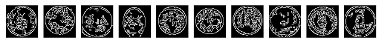

```python
plot_imagenes(imgs_w_filtro)
```

```python
# imgs_w_filtro = [cv2.resize(img, (64, 64)) for img in imgs_w_filtro]
imgs_w_filtro = np.array(imgs_w_filtro, dtype = np.int64)
imgs_w_filtro = imgs_w_filtro / 255
```

```python
imgs_w_filtro_expanded = np.expand_dims(imgs_w_filtro, axis=-1)
pred = modelo_rupias_filtro.predict(imgs_w_filtro_expanded, verbose = 1)
pred = np.argmax(pred, axis = 1)
pred = encoder.inverse_transform(pred)
pred
```

```
1/1 ━━━━━━━━━━━━━━━━━━━━ 0s 106ms/step
```

```
array(['5rupias', '1rupia', '1rupia', '1rupia', '1rupia', '1rupia',
       '1rupia', '5rupias', '2rupias', '5rupias'], dtype='<U7')
```

**Se obtienen mejores resultados utilizando el filtro canny? Por qué? ** Bueno en la predicción si mejoró, pero muy poco, pasamos de adivinar 5/10, a adivinar 6/10.

De las 10 monedas anteriores con el orden: 5rupia, 2rupia, 1rupia, 1rupia, 1rupia, 2rupia, 2rupia, 5rupia, 5rupia, 5rupia.

El filtro canny dectecta bordes, por lo que se pueden encontrar patrones más facilmente, xq elimina los restos de información que no son tan relevantes. Creo que en este caso talvez no cumplió tanto su función porque las imágenes se empezaron a trabajar de 64x64 y creo que perdio bastante información, aunque usando un desenfoque gausiano para eliminar ruido, a canny le costó un poco más identificar bien los bordes importantes. Se trató de manejar desde el tamaño original(256x256) y reducirlo hasta 64x64, con la idea de mejorar los resultados, sin embargo, por falta de poder computacional se decidio dejarlo en 64x64.